# My SpotifyR report

Author

Hana Yang

# About Ed Sheeran

## Who is Ed Sheeran?

A guy who loves ketchup.

[figure not shown]

and Lego

[figure not shown]

### His Quote

> *“Success is the best revenge of anything.”*

> -Ed Sheeran

### His albums

- “+” (Released in 2011)
- “×” (2014)
- “÷” (2017)
- “=” (2021)

## My picks

### My favorite album

[figure not shown]

## Data Analysis

### Import data

```r
# These are packages I need for the analysis
#install.packages("ggplot2")
library(ggplot2)
library(dplyr)

# Import data into df
df <- read.csv("Ed_Sheeran.csv")
```

### Data Frame

```r
#slice 5 random records in the dataframe
df |> dplyr::slice_sample(n=5) |> knitr::kable(digits = 2)
```

| artist_name | track_name | track_number | album_name | album_release_year | energy | valence | danceability | loudness | speechiness | liveness | tempo | key_mode | duration_ms |
| --- | --- | --- | --- | --- | --- | --- | --- | --- | --- | --- | --- | --- | --- |
| Ed Sheeran | 2step (feat. Denise Chaila) | 13 | 2step (The Remixes) | 2021 | 0.69 | 0.49 | 0.73 | -4.79 | 0.08 | 0.11 | 94.99 | G major | 153227 |
| Ed Sheeran | Cross Me (feat. Chance the Rapper & PnB Rock) | 3 | No.6 Collaborations Project | 2019 | 0.79 | 0.61 | 0.75 | -6.37 | 0.12 | 0.07 | 95.00 | E major | 206186 |
| Ed Sheeran | Runaway | 9 | x (Wembley Edition) | 2015 | 0.45 | 0.91 | 0.77 | -7.16 | 0.04 | 0.15 | 95.03 | G# minor | 205133 |
| Ed Sheeran | Toughest - Bonus Track | 17 | - (Deluxe) | 2023 | 0.55 | 0.48 | 0.62 | -7.08 | 0.03 | 0.13 | 133.30 | D# major | 213768 |
| Ed Sheeran | Lay It All on Me (feat. Ed Sheeran) | 23 | x (Wembley Edition) | 2015 | 0.75 | 0.48 | 0.67 | -7.11 | 0.04 | 0.18 | 122.53 | F# major | 242440 |

## Data preparation

Since there are some duplicated tracks, I’ve cleaned them. Also, I removed the tracks in live versions of the same songs.

```r
# Remove records with the same track names
df <- df |> distinct(track_name, .keep_all = TRUE)
# Filter out track names that include "Live at" or "Live Acoustic"
df <- df |> filter(!grepl("Live at|Live Acoustic", track_name))
# Filter out album names that include Living" or "collaboration"
df <- df |> filter(!grepl("Living|Project|Remixes", album_name))
# Change the data type of album_name from numeric into character
df$album_name <- as.character(df$album_name)
```

### Album analysis

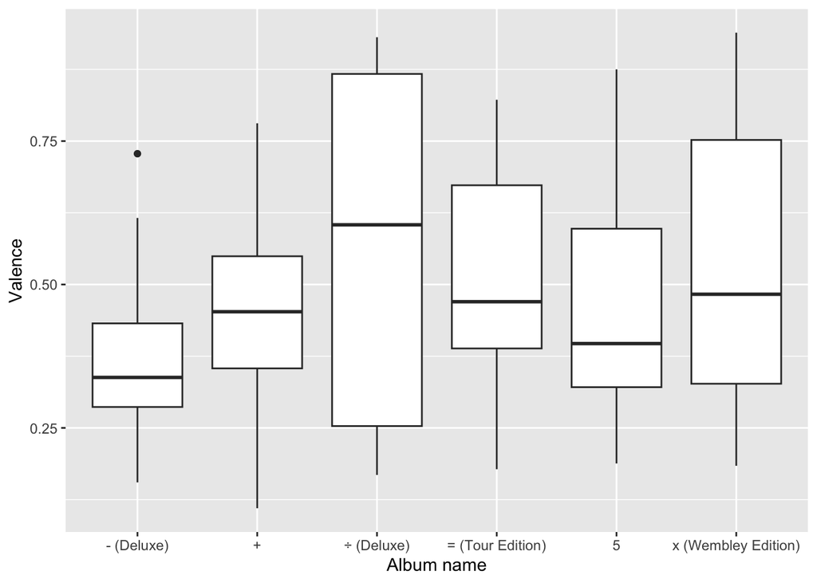

```r
# Change album_name from character to factor before plotting
df$album_name <- as.factor(df$album_name)
# Plot a boxplot
ggplot(df, aes(x=album_name, y=valence))+
  geom_boxplot()+
  labs(x="Album name", y="Valence")
```

÷(divide) has the highest valence in average which the album published in 2017, right before Ed Sheeran got married.

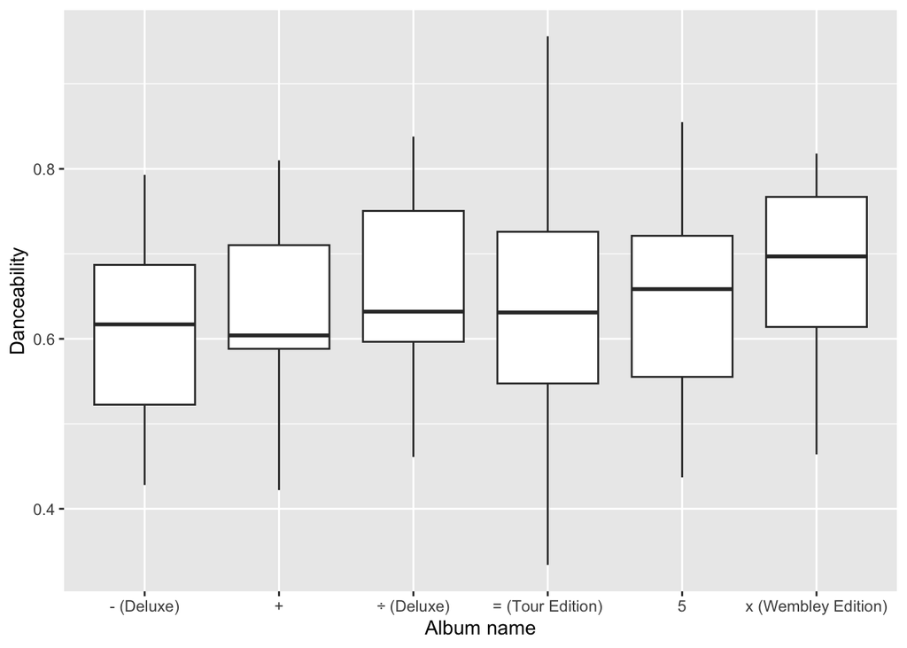

```r
# Plot a boxplot
ggplot(df, aes(x=album_name, y=danceability))+
  geom_boxplot()+
  labs(x="Album name", y="Danceability")
```

We further look into danceability to check how extra happy he was but this does not give the result we expected.

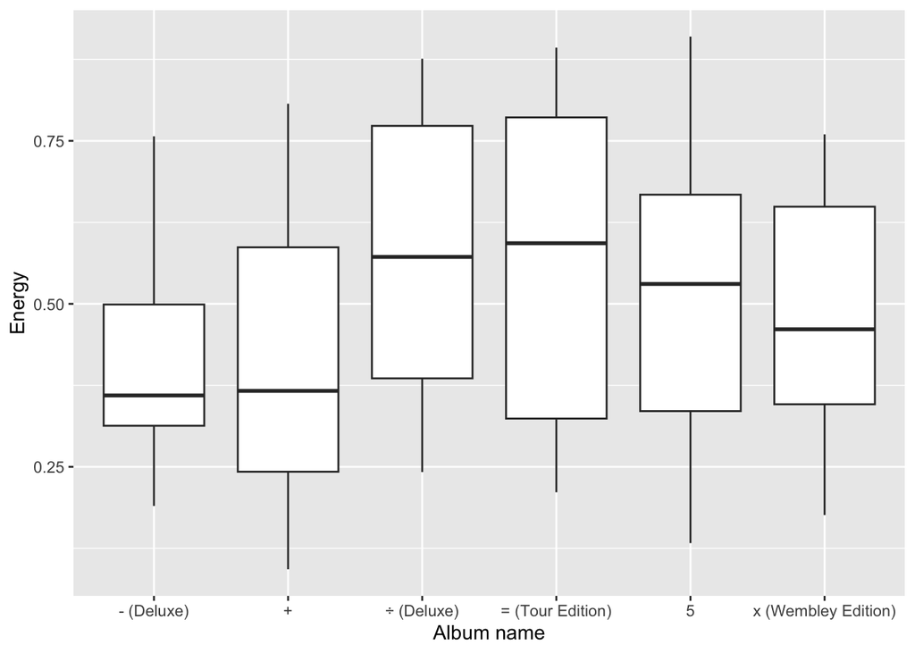

```r
ggplot(df, aes(x=album_name, y=energy))+
  geom_boxplot()+
  labs(x="Album name", y="Energy")
```

## My TOP song Analysis

```r
#create data
TOP5 <-df|> filter(track_name %in% c("Shivers", "What Do I Know?", "Nancy Mulligan", "New Man", "Galway Girl"))

#Print
print(TOP5)
```

```
  artist_name      track_name track_number       album_name album_release_year
1  Ed Sheeran     Galway Girl            6       ÷ (Deluxe)               2017
2  Ed Sheeran  Nancy Mulligan           15       ÷ (Deluxe)               2017
3  Ed Sheeran         New Man            8       ÷ (Deluxe)               2017
4  Ed Sheeran         Shivers            2 = (Tour Edition)               2022
5  Ed Sheeran What Do I Know?           10       ÷ (Deluxe)               2017
  energy valence danceability loudness speechiness liveness   tempo key_mode
1  0.876   0.781        0.624   -3.374      0.1000   0.3270  99.943  A major
2  0.852   0.858        0.680   -4.350      0.0349   0.0866 101.993  G major
3  0.745   0.862        0.780   -3.970      0.1450   0.0595  94.026  G major
4  0.859   0.822        0.788   -2.724      0.0856   0.0424 141.020  D major
5  0.492   0.895        0.838   -5.690      0.0380   0.2620 115.092 C# minor
  duration_ms
1      170826
2      179786
3      189280
4      207853
5      237333
```

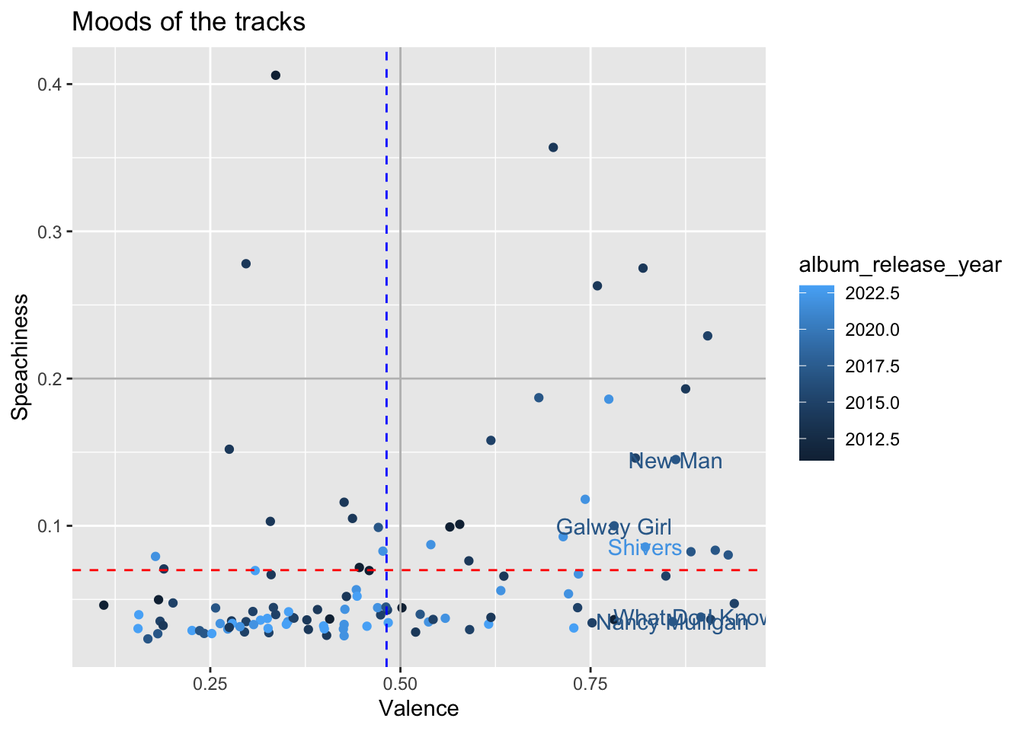

```r
#average
av_tempo <- mean(df$tempo)
av_speachiness <- mean(df$speechiness)
av_valence <- mean(df$valence)

#scatterplot for valence vs energy
scatter_plot2 <- ggplot(df, aes(x = valence, y = speechiness, color = album_release_year)) +
  geom_point() +
  geom_hline(yintercept = 0.2, color = "grey") +
  geom_vline(xintercept = 0.5, color = "grey") +
  geom_hline(yintercept = av_speachiness, linetype = "dashed", color = "red") +
  geom_vline(xintercept = av_valence, linetype = "dashed", color = "blue") +
  geom_text(data=TOP5, aes(label=track_name)) +
  labs(title = "Moods of the tracks",
       x = "Valence",
       y = "Speachiness")

# Print or display the plot
print(scatter_plot2)
```

Here we can see that Ed Sheeran’s song in general do not possess high level of speachiness. Showing that it is not a significant factor influencing my preference.

Maybe energy,,,?

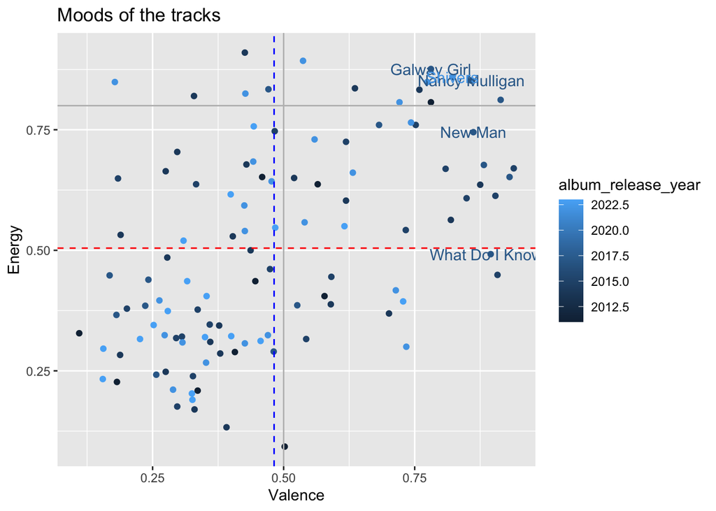

```r
#calculate the avg
av_energy <- mean(df$energy)

#scatterplot for valence vs energy
scatter_plot <- ggplot(df, aes(x = valence, y = energy, color = album_release_year)) +
  geom_point() +
  geom_hline(yintercept = 0.8, color = "grey") +
  geom_vline(xintercept = 0.5, color = "grey") +
  geom_hline(yintercept = av_energy, linetype = "dashed", color = "red") +
  geom_vline(xintercept = av_valence, linetype = "dashed", color = "blue") +
  geom_text(data=TOP5, aes(label=track_name)) +
  labs(title = "Moods of the tracks",
       x = "Valence",
       y = "Energy")

# Print or display the plot
print(scatter_plot)
```

4 out of 5 Top Songs has higher value then average in Energy and Valence. Only ‘what do I know?’ has a energy which is below average but maintaining a high valence.

It seems like I really like a song with positive atmosphere.

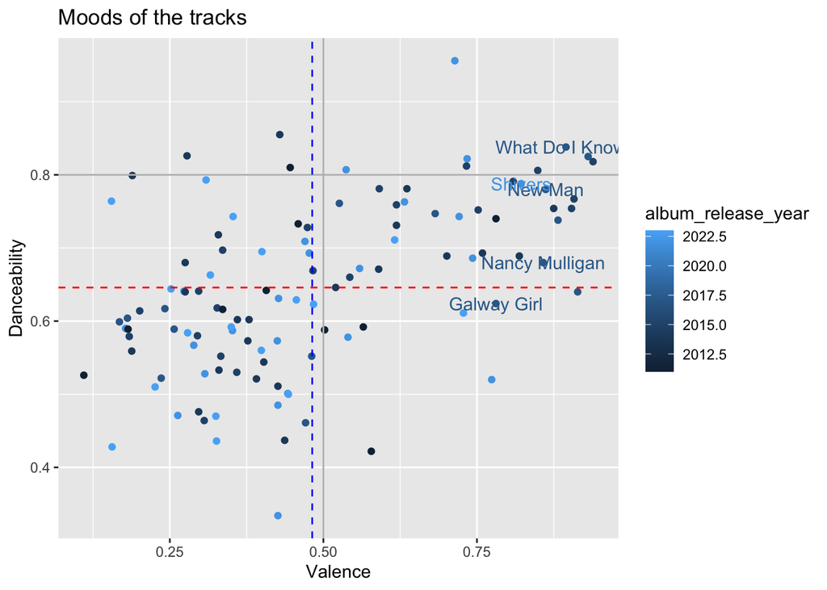

```r
#avg
av_danceability <- mean(df$danceability)


#scatterplot for valence vs energy
scatter_plot3 <- ggplot(df, aes(x = valence, y = danceability, color = album_release_year)) +
  geom_point() +
  geom_hline(yintercept = 0.8, color = "grey") +
  geom_vline(xintercept = 0.5, color = "grey") +
  geom_hline(yintercept = av_danceability, linetype = "dashed", color = "red") +
  geom_vline(xintercept = av_valence, linetype = "dashed", color = "blue") +
  geom_text(data=TOP5, aes(label=track_name)) +
  labs(title = "Moods of the tracks",
       x = "Valence",
       y = "Danceability")

# Print or display the plot
print(scatter_plot3)
```

Now we have “Galway Girl” below the average but without that, 4 out of 5 songs are maintaining high level of danceability.

## Which song would you recommend to Ed Sheeran Beginners.

### Spotify Top Songs by Ed Sheeran

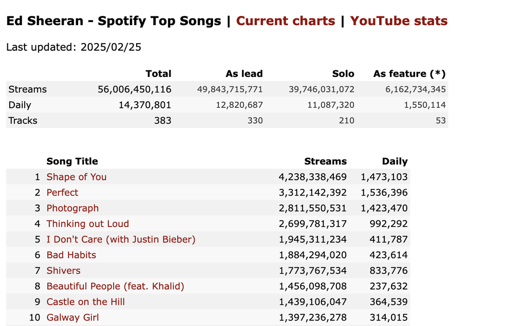

https://kworb.net/spotify/artist/6eUKZXaKkcviH0Ku9w2n3V_songs.html#google_vignette

```r
subgroup <-df|> filter(track_name %in% c("Shape of You", "Perfect", "Photograph", "Thinking out Loud", "Bad Habits", "Shivers", "Beautiful People", "Castle on the Hill", "Galway Girl"))

#high tempo song
subgroup |> slice_max(tempo, n=3) |> dplyr::select(track_name, album_name, album_release_year, tempo) |> knitr::kable(digits = 2)
```

| track_name | album_name | album_release_year | tempo |
| --- | --- | --- | --- |
| Shivers | = (Tour Edition) | 2022 | 141.02 |
| Castle on the Hill | ÷ (Deluxe) | 2017 | 135.01 |
| Bad Habits | = (Tour Edition) | 2022 | 126.01 |

```r
#valence check
subgroup |> slice_max(valence, n=3) |> dplyr::select(track_name, album_name, album_release_year, valence) |> knitr::kable(digits = 2)
```

| track_name | album_name | album_release_year | valence |
| --- | --- | --- | --- |
| Shape of You | ÷ (Deluxe) | 2017 | 0.93 |
| Shivers | = (Tour Edition) | 2022 | 0.82 |
| Galway Girl | ÷ (Deluxe) | 2017 | 0.78 |

```r
#energy check
subgroup |> slice_max(energy, n=3) |> dplyr::select(track_name, album_name, album_release_year, energy) |> knitr::kable(digits = 2)
```

| track_name | album_name | album_release_year | energy |
| --- | --- | --- | --- |
| Bad Habits | = (Tour Edition) | 2022 | 0.89 |
| Galway Girl | ÷ (Deluxe) | 2017 | 0.88 |
| Shivers | = (Tour Edition) | 2022 | 0.86 |

```r
#loudness check
subgroup |> slice_max(loudness, n=3) |> dplyr::select(track_name, album_name, album_release_year, loudness) |> knitr::kable(digits = 2)
```

| track_name | album_name | album_release_year | loudness |
| --- | --- | --- | --- |
| Shivers | = (Tour Edition) | 2022 | -2.72 |
| Shape of You | ÷ (Deluxe) | 2017 | -3.18 |
| Galway Girl | ÷ (Deluxe) | 2017 | -3.37 |

### Result

Shievers seem like the most go to for the person who likes explosive music.

Ranked in 4 different figures (energy, loudness, valence, tempo).

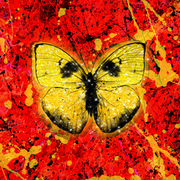

[video not shown]